# Plotting Multidimensional Scaling using ggplot2 and ggfortify

This document explains MDS (Multidimensional Scaling) plotting using `ggplot2` and `ggfortify`.

# Installation

First, install `ggfortify` from [github](https://github.com/sinhrks/ggfortify).

```r
library(devtools)
install_github('sinhrks/ggfortify')
```

# Before Plotting

`ggfortify` let `ggplot2` know how to interpret some popular R classes. However, you cannot use `autoplot` directly for MDS because MDS functions return `matrix` or `list`, not specific class. Thus, `ggfortify` cannot define `autoplot` for MDS. You have to create an intended plot using `matrix` by yourselves.

# Plotting Matrix

`ggfortify` defines `autoplot.matrix` to plot either heatmap or scatter plot.

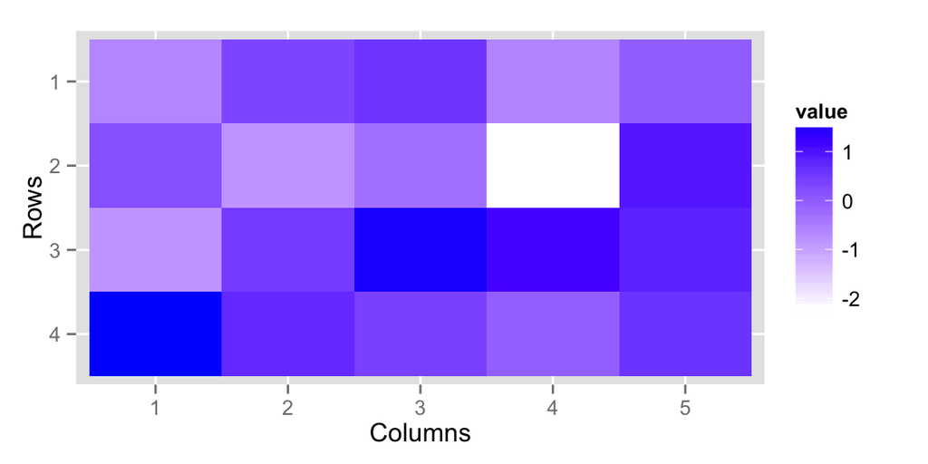

```r
library(ggplot2)
library(ggfortify)

set.seed(1)
# heatmap
m <- matrix(rnorm(20), nc = 5)
autoplot(m)
```

Specifying `geom = 'point'` outputs scatter plot. Target `matrix` should have exactly 2 columns to draw scatter plot.

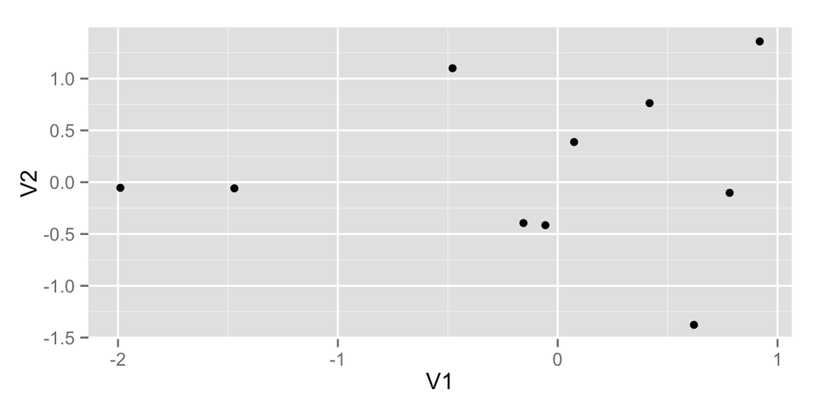

```r
# scatter plot
m <- matrix(rnorm(20), nc = 2)
autoplot(m, geom = 'point')
```

**NOTE** Also, `ggfortify` can plot `stats::dist` instance as heatmap.

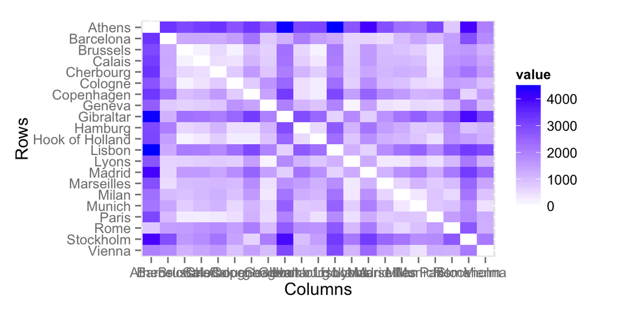

```r
data(eurodist)
d.dist <- eurodist
autoplot(d.dist)
```

# Plotting Classical (Metric) Multidimensional Scaling

`stats::cmdscale` performs Classical MDS and returns point coodinates as `matrix`, you should call `autplot` as below. Specify `label = TRUE` to plot labels.

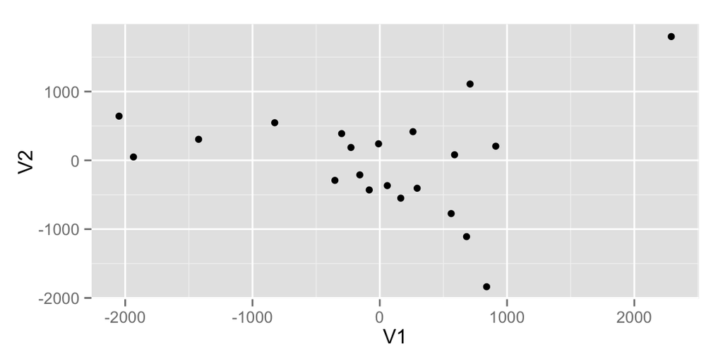

```r
autoplot(cmdscale(d.dist), geom = 'point')
```

```r
autoplot(cmdscale(d.dist), geom = 'point', label = TRUE)
```

[output not shown]

`stats::cmdscale` may return `list` depending on some options. For details, refer to `help(cmdscale)`. In these cases, point coordinates must be explicitly passed to `autoplot`.

```r
autoplot(cmdscale(d.dist, eig = TRUE)$points, geom = 'point', label = TRUE)
```

[output not shown]

Also, if the dimension of point coordinates is not 2, slice coordinates used for plotting.

```r
autoplot(cmdscale(d.dist, eig = TRUE, k = 3)$points[, 1:2], geom = 'point', label = TRUE)
```

[output not shown]

# Plotting Non-metric Multidimensional Scaling

`MASS::isoMDS` and `MASS::sammon` perform Non-metric MDS and return `list` which contains point coordinates. Thus, `autoplot` should be called as below.

**NOTE** There are some common configurable options. For details, see `help(autoplot.matrix)`.

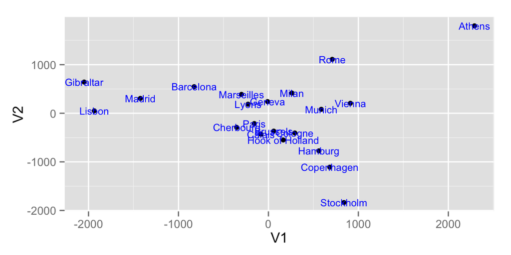

```r
library(MASS)
autoplot(isoMDS(d.dist)$points, geom = 'point', label = TRUE, colour = 'blue',
         label.size = 3, label.colour = 'blue')
```

```
## Initial stress        : 0.01705
## stress after  10 iters: 0.00951, magic = 0.500
## stress after  20 iters: 0.00941, magic = 0.500
```

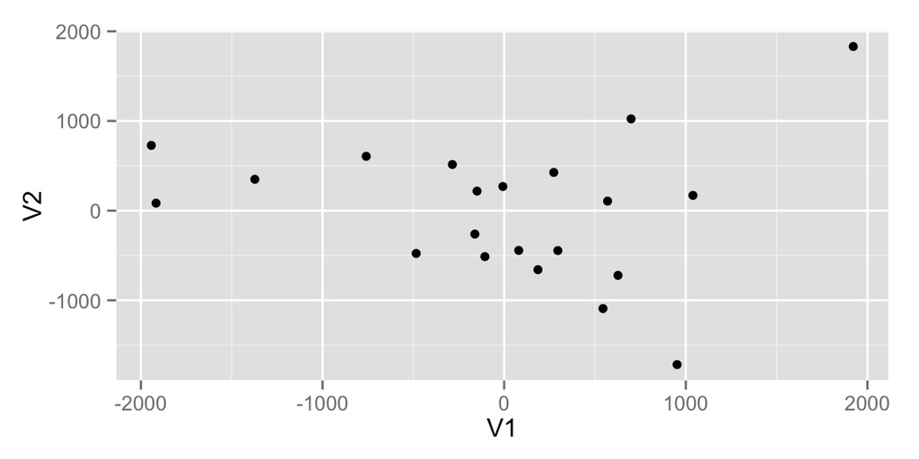

```r
autoplot(sammon(d.dist)$points, geom = 'point', label = FALSE, colour = 'green')
```

# Resources related to ggfortify

- [Plotting Diagnostics for LM and GLM with ggplot2 and ggfortify](http://rpubs.com/sinhrks/plot_lm)
- [Plotting Time Series with ggplot2 and ggfortify](http://rpubs.com/sinhrks/plot_ts)
- [Plotting Time Series Statistics with ggplot2 and ggfortify](http://rpubs.com/sinhrks/plot_tsstats)
- [Plotting PCA/clustering results using ggplot2 and ggfortify](http://rpubs.com/sinhrks/plot_pca)
- [Plotting Multidimensional Scaling using ggplot2 and ggfortify](http://rpubs.com/sinhrks/plot_mds)
- [Plotting Survival Curves using ggplot2 and ggfortify](http://rpubs.com/sinhrks/plot_surv)
- [Plotting Probability Distributions with ggplot2 and ggfortify](http://rpubs.com/sinhrks/plot_dist)